# Predictive Analysis

Jason Eastman, Katie Gentry, Ricky Duran

May 01, 2020

# Predictive Analysis

Using the New Market Tax Credits and Low Income Tax Credits, we can also run some predictive analysis on Median Home Value and Growth. First, we’ll want to get the data ready for analysis.

## Libraries

Here are the libraries to be used in the process.

```r
library( dplyr )
library( knitr )
library( pander )
library( stargazer )
library( scales )
library( ggplot2 )
library( gridExtra )
library( here )

set.seed( 1234 )

s.type <- "html"
```

## Load and Merge Datasets

Census data from 2000 and 2010 are downloaded along with its metadata. Then the data is merged into one datset. the IDs are also updated to match the fed IDs.

```r
census_2000 <- readRDS( "data/rodeo/LTDB-2000.rds" )
census_2010 <- readRDS( "data/rodeo/LTDB-2010.rds" )
meta_data <- readRDS( "data/rodeo/LTDB-META-DATA.rds" )

census_2000 <- select( census_2000, - year )
census_2010 <- select( census_2010, - year )

merged_census <- merge( census_2000, census_2010, by="tractid" )
merged_census <- merge( merged_census, meta_data, by="tractid" )

# remove anything not a number from the string
merged_census$id2 <- gsub( "[^0-9]", "", merged_census$tractid )

# fix IDs so they are match to fed data
merged_census$id2 <- as.numeric( merged_census$id2 )
```

## Add Federal Data

Both NMTC and LIHTC data is downlaoded.

```r
URL1 <- "https://raw.githubusercontent.com/DS4PS/cpp-528-spr-2020/master/labs/data/raw/NMTC/nmtc-sheet-01.csv"
nmtc <- read.csv( URL1, stringsAsFactors=F )

URL <- "https://raw.githubusercontent.com/DS4PS/cpp-528-spr-2020/master/labs/data/raw/LIHTC/LIHTCPUB.csv"
lihtc <- read.csv( URL, stringsAsFactors=F )
```

# Aggregate Credits Given Between 2000 and 2010

```r
# LIHTC
lihtc.dollars <-
  lihtc %>%
  filter( yr_alloc >= 2000 & yr_alloc <= 2010 ) %>%
  group_by( fips2010 ) %>%
  summarize( num.lihtc = n(), lihtc.total = sum( allocamt, na.rm=T ) )

# NMTC
# need to convert from currency to numeric
# current format:
# head( nmtc$QLICI.Amount )
# [1] "$300,000.00 "   "$1,008,750.00 " "$977,000.00 "

# remove dollar sign and commas
nmtc$amount <- gsub( "[,$]", "", nmtc$QLICI.Amount )

# head(  nmtc$amount  )
# "300000.00 "  "1008750.00 " "977000.00 "

# convert characters to numeric
nmtc$amount <- as.numeric( nmtc$amount ) %>% round(0)

# head(  nmtc$amount  )
# [1]  300000 1008750  977000

nmtc.dollars <-
  nmtc %>%
  filter( Origination.Year >= 2000 & Origination.Year <= 2010 ) %>%
  group_by( X2010.Census.Tract ) %>%
  summarize( num.nmtc=n(), nmtc.total = sum( amount, na.rm=T ) )
```

## Merge Census and Tax Policy Data

```r
merged_census <- merge( merged_census, nmtc.dollars, by.x="id2", by.y="X2010.Census.Tract", all.x=T )
merged_census <- merge( merged_census, lihtc.dollars, by.x="id2", by.y="fips2010", all.x=T )

# recode tracts that had no grants from NA to 0

merged_census$num.nmtc[ is.na(merged_census$num.nmtc) ] <- 0
merged_census$nmtc.total[ is.na(merged_census$nmtc.total) ] <- 0

merged_census$num.lihtc[ is.na(merged_census$num.lihtc) ] <- 0
merged_census$lihtc.total[ is.na(merged_census$lihtc.total) ] <- 0
```

## Remove Rural Districts

```r
data_urban <- filter( merged_census, urban == "urban" )
```

## Calculate Median Home Value Variables

```r
# adjust 2000 home values for inflation
mhv.00 <- data_urban$mhmval00 * 1.28855
mhv.10 <- data_urban$mhmval12

# find Median Home Value change from 2000 to 2010
mhv.change <- mhv.10 - mhv.00

# Fliter out home values less than 10k
mhv.00[ mhv.00 < 1000 ] <- NA
pct.change <- 100 * ( mhv.change / mhv.00 )

#Add variables back into dataset
data_urban$mhv.00 <- mhv.00
data_urban$mhv.10 <- mhv.10
data_urban$mhv.change <- mhv.change
data_urban$pct.change <- pct.change
```

## Calculate New Statistical Variables

Here is where new variables are calculated. These variables include many percentages and changes between 2000 and 2010. the dataset is also grouped to create metro-wide variables as well.

```r
# Calculate new variables
data_urban <-
  data_urban %>%
  mutate(
          # 2000 variables
          p.white.00 = 100 * nhwht00 / pop00.x,
          p.black.00 = 100 * nhblk00 / pop00.x,
          p.hisp.00 = 100 * hisp00 / pop00.x,
          p.asian.00 = 100 * asian00 / pop00.x,
          p.col.edu.00 = 100 * col00 / ag25up00,
          p.prof.00 = 100 * prof00 / empclf00,
          p.unemp.00 = 100 * unemp00 / clf00,
          pov.rate.00 = 100 * npov00 / dpov00,
          p.rent.00 = 100 * rent00 / hu00,
          p.selfemp.00 = 100 * semp00 / empclf00,

          # 2010 variables
          p.white.10 = 100 * nhwht10 / pop10,
          p.black.10 = 100 * nhblk10 / pop10,
          p.hisp.10 = 100 * hisp10 / pop10,
          p.asian.10 = 100 * asian10 / pop10,
          p.col.edu.10 = 100 * col12 / ag25up12,
          p.prof.10 = 100 * prof12 / empclf12,
          p.unemp.10 = 100 * unemp12 / clf12,
          pov.rate.10 = 100 * npov12 / dpov12,
          p.rent.10 = 100 * rent10 / hu10,
          p.selfemp.10 = 100 * semp12 / empclf12)

# inflation adjust income
data_urban$hinc00 <- 1.28855 * data_urban$hinc00

# Calculate new variables using "group_by"
data_urban <-
  data_urban %>%
  group_by( cbsaname ) %>%
  mutate( metro.mhv.pct.00 = ntile( mhv.00, 100 ),
          metro.mhv.pct.10 = ntile( mhv.10, 100 ),
          metro.median.pay.00 = median( hinc00, na.rm=T ),
          metro.median.pay.10 = median( hinc12, na.rm=T ),
          metro.diversity.rank.00 = ntile( (100-p.white.00), 100 ),
          # metro total population 2000
          metro.pop.total.00 = sum( pop00.x, na.rm=T ),
          # metro total population 2010
          metro.pop.total.10 = sum( pop10, na.rm=T ),
          # tract rank in metro area for unemployment in 2000
          metro.unemp.rank.00 = ntile( p.unemp.00, 100 ),
          # tract rank in metro area for unemployment in 2010
          metro.unemp.rank.10 = ntile( p.unemp.10, 100 ) ) %>%
  ungroup() %>%
  mutate( metro.mhv.pct.change = metro.mhv.pct.10 - metro.mhv.pct.00,
          # metro population growth 2000-2010
          metro.pop.growth =
            ( metro.pop.total.10 - metro.pop.total.00 ) / metro.pop.total.00,
          metro.unemp.pct.change = metro.unemp.rank.10 - metro.unemp.rank.00,
          pay.change = metro.median.pay.10 - metro.median.pay.00,
          race.change = p.white.10 - p.white.00,
          pov.change = pov.rate.10 - pov.rate.00,
          p.unemp.change = p.unemp.10 - p.unemp.00,
          p.col.edu.change = p.col.edu.10 - p.col.edu.00,
          p.rent.change = p.rent.10 - p.rent.00,
          # increase in the proportion of self-employed in tract
          increase.p.selfemp = p.selfemp.10 - p.selfemp.00)

# Keep only variables we need
data_urban <-
  data_urban %>%
  select( c( "tractid", "cbsa", "cbsaname",
          "mhv.00", "mhv.10", "mhv.change","pct.change",
          "p.white.00", "p.black.00", "p.hisp.00", "p.asian.00",
          "p.col.edu.00", "p.prof.00",  "p.unemp.00", "pov.rate.00",
          "metro.mhv.pct.00", "metro.median.pay.00", "metro.pop.total.00",
          "metro.unemp.pct.change", "metro.unemp.rank.00",
          "metro.pop.growth", "metro.mhv.pct.change", "pay.change", "race.change",
          "metro.diversity.rank.00", "pov.change", "p.unemp.change",
          "p.col.edu.change", "p.rent.change",
          "metro.mhv.pct.10", "metro.median.pay.10", "metro.pop.total.10",
          "p.white.10", "p.black.10", "p.hisp.10", "p.asian.10",
          "p.col.edu.10", "p.prof.10",
          "p.unemp.10", "pov.rate.10", "metro.unemp.rank.10",
          "num.lihtc", "lihtc.total", "num.nmtc", "nmtc.total",
          "p.selfemp.00", "p.selfemp.10", "increase.p.selfemp"
          ) )
```

## Save Dataset to File

At this point, a concise and tidy dataset has been created, so saving it as a file is wise.

```r
file.name <- paste0( "data/rodeo/urban_census.rds" )
  saveRDS( data_urban, file.name )
```

# Update Models Adding Tax Credit Amounts

## Clean up Dataset for Modeling

In this code, we’re creating True/False values for whether NMTC or LIHTC tax credits were given. Next is logging the Median Home Values for 2000 and 2010. Finally, a treatment variable is created to distinguish tax credit. Now let’s look at how our chosen variables stack up with recipients and non-recipients of the two tax credits.

```r
# Create a true/false code for recipient tracts
data_urban$LIHTC <- ifelse( data_urban$num.lihtc > 0, "YES", "NO" )
data_urban$NMTC <- ifelse( data_urban$num.nmtc > 0, "YES", "NO" )

# Log Median Home Value
y1 <- log( data_urban$mhv.00 )
y2 <- log( data_urban$mhv.10 )

treat.nmtc <- as.numeric( data_urban$num.nmtc > 0 )
treat.lihtc <- as.numeric( data_urban$num.lihtc > 0 )
```

## Self-Employment

For both NMTC and LIHTC recipients, it shows that there was less of a percentage of self-employment, but at a higher density than the non-recipients.

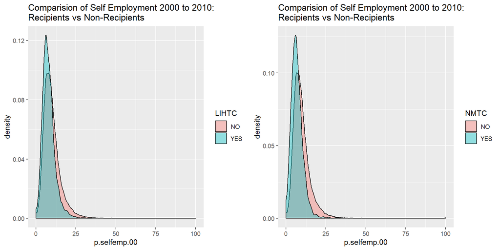

```r
### Self-Employment

p3 <-
  ggplot( data_urban, aes(x=p.selfemp.00, fill=LIHTC )) +
  geom_density( alpha=0.4 )  +
  ggtitle("Comparision of Self Employment 2000 to 2010: \nRecipients vs Non-Recipients")

p4 <-
ggplot( data_urban, aes(x=p.selfemp.00, fill=NMTC )) +
  geom_density( alpha=0.4 )  +
  ggtitle("Comparision of Self Employment 2000 to 2010: \nRecipients vs Non-Recipients")

grid.arrange( p3, p4, nrow = 1 )
```

## Unemployment

Unemplpyment shows a much different set of grpahs. Recipients of both NMTC and LIHTC tax credits, have a higher percentage but a lower density.

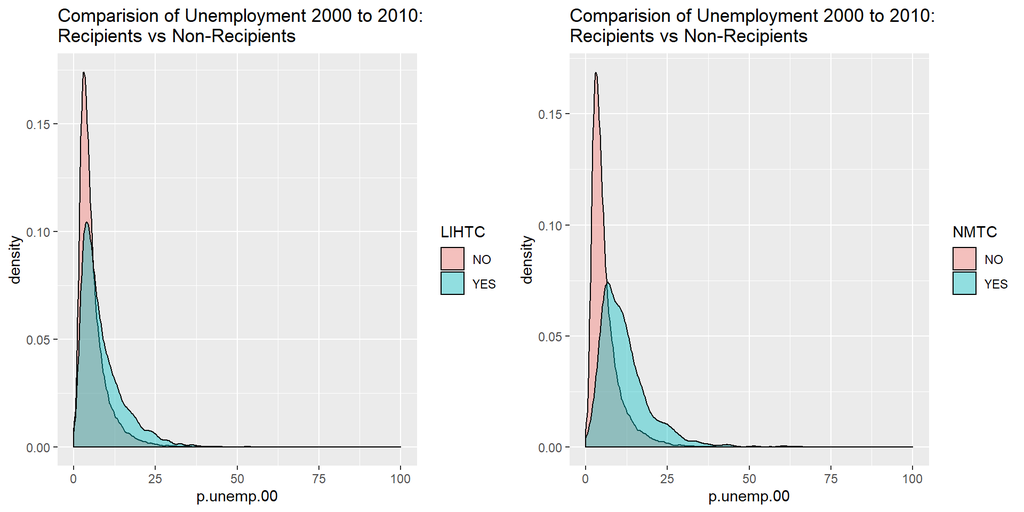

```r
### Unemployment

p5 <-
  ggplot( data_urban, aes(x=p.unemp.00, fill=LIHTC )) +
  geom_density( alpha=0.4 )  +
  ggtitle("Comparision of Unemployment 2000 to 2010: \nRecipients vs Non-Recipients")

p6 <-
ggplot( data_urban, aes(x=p.unemp.00, fill=NMTC )) +
  geom_density( alpha=0.4 )  +
  ggtitle("Comparision of Unemployment 2000 to 2010: \nRecipients vs Non-Recipients")

grid.arrange( p5, p6, nrow = 1 )
```

## Metro Median Pay

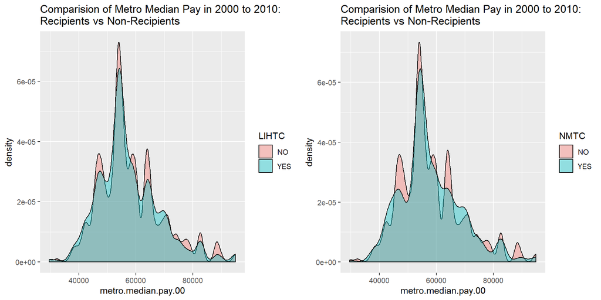

```r
### Metro Median Pay

p7 <-
  ggplot( data_urban, aes(x=metro.median.pay.00, fill=LIHTC )) +
  geom_density( alpha=0.4 )  +
  ggtitle("Comparision of Metro Median Pay in 2000 to 2010: \nRecipients vs Non-Recipients")

p8 <-
ggplot( data_urban, aes(x=metro.median.pay.00, fill=NMTC )) +
  geom_density( alpha=0.4 )  +
  ggtitle("Comparision of Metro Median Pay in 2000 to 2010: \nRecipients vs Non-Recipients")

grid.arrange( p7, p8, nrow = 1 )
```

## Difference-in-Difference Model

Looking at the Difference in Difference model, we see that both NMTC and LIHTC tax credits show a highly similar pattern for the chosen control variables.

```r
data_2000 <- data.frame(y = y1, treat = treat.nmtc, post = 0, percent.selfemployed = data_urban$p.selfemp.00, metro.median.pay = data_urban$metro.median.pay.00, percent.unemployed = data_urban$p.unemp.00)
data_2010 <- data.frame(y = y2, treat = treat.nmtc, post = 1, percent.selfemployed = data_urban$p.selfemp.10, metro.median.pay = data_urban$metro.median.pay.10, percent.unemployed = data_urban$p.unemp.10)
data_both <- rbind(data_2000,  data_2010)


nmtc_reg <- lm(y ~ treat + post + treat * post + percent.selfemployed + metro.median.pay + percent.unemployed, data = data_both)


data2_2000 <- data.frame(y = y1, treat = treat.lihtc, post = 0, percent.selfemployed = data_urban$p.selfemp.00, metro.median.pay = data_urban$metro.median.pay.00, percent.unemployed = data_urban$p.unemp.00)
data2_2010 <- data.frame(y = y2, treat = treat.lihtc, post = 1, percent.selfemployed = data_urban$p.selfemp.10, metro.median.pay = data_urban$metro.median.pay.10, percent.unemployed = data_urban$p.unemp.10)
data2_both <- rbind(data2_2000,  data2_2010)


lihtc_reg <- lm(y ~ treat + post + treat * post + percent.selfemployed + metro.median.pay + percent.unemployed, data = data2_both)


stargazer( nmtc_reg, lihtc_reg,
           type=s.type,
           digits=2
           )
```

|  | *Dependent variable:* |  |
| --- | --- | --- |
|  | y |  |
|  | (1) | (2) |
| treat | -0.03** | -0.05*** |
|  | (0.01) | (0.01) |
| post | 0.37*** | 0.37*** |
|  | (0.003) | (0.003) |
| percent.selfemployed | 0.04*** | 0.04*** |
|  | (0.0003) | (0.0003) |
| metro.median.pay | 0.0000*** | 0.0000*** |
|  | (0.0000) | (0.0000) |
| percent.unemployed | -0.02*** | -0.02*** |
|  | (0.0002) | (0.0002) |
| treat:post | 0.04** | 0.01 |
|  | (0.02) | (0.01) |
| Constant | 10.14*** | 10.14*** |
|  | (0.01) | (0.01) |
| Observations | 118,707 | 118,707 |
| R<sup>2</sup> | 0.49 | 0.49 |
| Adjusted R<sup>2</sup> | 0.49 | 0.49 |
| Residual Std. Error (df = 118700) | 0.46 | 0.46 |
| F Statistic (df = 6; 118700) | 19,334.10*** | 19,380.28*** |
| *Note:* | p<0.1; p<0.05; p<0.01 |  |